#Introdução

A represa do Fazzari, localizada na cidade de São Carlos de clima tropical, teve sua composição natural alterada devido aos dejetos químicos. No processo, nanopartículas de óxido de zinco e sal de zinco são os principais componentes incorporados às águas fluviais.

Um dos componentes da vida no rio são os microcrustáceos, animais que fazem parte do zooplâncton e a principal fonte de alimentação e transferência de energia para os níveis tróficos superiores do ambiente em questão. Em outras palavras, os microcrustáceos são microorganismos que servem como principal fonte de alimentação para outras espécies, que, por sua vez, são a principal fonte de alimentação para outras espécies e, assim, sucessivamente, até que se complete a biodiversidade do rio.

#Objetivo

Considerada a importância da existência regulada dos microcrustáceos como base da cadeia alimentar, para a sustentabilidade da biodiversidade da represa do Fazzari, o presente trabalho tem por objetivo a análise do impacto das nanopartículas de óxido de zinco e do sal de zinco no:

1. desenvolvimento - tamanho (comprimento em milímetros) que os microorganismos em questão atingem;
2. fecundação - quantidade de zigotos formados por dia;
3. nascimento - quantidade de zigotos que se transformam em indivíduos adultos;

Os impactos serão mensurados e analisados através da comparação entre 6 cenários, caracterizados pela ausência dos componentes destacados na água e outras cinco concentrações dos mesmos.

#Banco de dados

O banco de dados considerado para as análises contém 1080 observações, de 120 microcrustáceos divididos em 12 grupos - com 10 microcrustáceos em cada - dos quais 6 foram expostos às nanopartículas e 6 ao sal de zinco. Para cada um dos 6 grupos submetidos a um dos materiais foram utilizadas 6 concentrações do mesmo (uma para cada grupo): 0,00 (controle), 0,006mg/L, 0,01mg/L, 0,02mg/L, 0,04mg/L e 0,09mg/L para o sal de zinco e 0,00 (controle), 0,006mg/L, 0,0125mg/L, 0,025mg/L, 0,05mg/L e 0,1mg/L para nanopartículas.

Os microcrustáceos foram observado durante 9 dias nos quais uma medida diária de seu comprimento (medido em milímetros), do número de ovos colocados no dia em questão e do número de neonatos nascidos neste dia.

Dados que faziam referência a morte do microcrustáceo foram retirados. Por exemplo, se no dia 8, a replicação 1 (microcrustáceo) morreu, este dado é desconsiderado. Isto fez com que as informações referentes ao dia diminuíssem para algumas concentrações nas quais isso ocorreu. (Poderia ser utilizada outra abordagem, como completar os dados faltantes por alguma técnica).

Além disso, para o sal de zinco, na variável “Tratamento” foram consideradas: “0” para controle, “1” para a concentração 0,006mg/L, “2” para a concentração 0,01mg/L, “3” para a concentração 0,02mg/L, “4” para a concentração 0,04mg/L e “5” para a concentração 0,09mg/L. Ideia semelhante foi adotada para nanopartículas: “0” para controle, “1” para a concentração 0,006mg/L, “2” para a concentração 0,0125mg/L, “3” para a concentração 0,025mg/L, “4” para a concentração 0,05mg/L e “5” para a concentração 0,1mg/L.

#Metodologia

Trata-se de um experimento com medições ao longo do tempo (nove dias, dados longitudinais) para microcrustáceos, das características comprimento, número de ovos e neonatos. Com isso, a teoria de modelos mistos foi utilizada para o entendimento das variáveis em relação ao controle e entre os tratamentos.

De maneira geral, modelos de efeitos mistos permitem que os coeficientes da regressão variem entre os indivíduos. Estes modelos têm dois componentes: um intra individual (mudança longitudinal intra individual é descrita pelo modelo de regressão com um intercepto e inclinação populacional) e outro entre indivíduos (variação no intercepto e inclinação individual).

As informações ou medidas dos indivíduos (no caso, microcrustáceos) não precisam ser igualmente espaçadas (no caso, tem-se medidas diárias, ou seja, de igual espaçamento) e balanceadas (tem-se a mesma quantidade de observação/replicação para cada tratamento, isto é, dados balanceados) e as análises podem ser conduzidas com os dados de indivíduos que foram perdidos de seguimento (pessoas que abandonaram o estudo, por exemplo) ou que apresentam ausência de informação em algum momento do estudo (no caso, microcrustáceos que morreram em algum dia para algum tratamento).

#Análise descritiva e exploratória

A seguir foram avaliadas as variáveis comprimento, número de ovos e nenonatos, de acordo com as informações dos 9 dias para nanopartículas e sal de zinco.

Conforme a descrição do banco de dados, entre as diferentes concentrações de nanopartículas e sal de zinco, somente uma coincide que é a concentração 0,006mg/L (definida como tratamento 1). Neste caso, uma breve avaliação foi feita em um tópico a parte.

##Comprimento para nanopartículas

De acordo com o diagrama de dispersão do comprimento por dia (figura 1) e do gráfico de perfil médio (figura 3), percebe-se que existe uma associação entre os valores do comprimento com o passar dos dias, ou seja, em geral ao longo dos dias aumenta-se o comprimento dos microcrustáceos. Além disso, nota-se que os comprimentos têm uma característica de crescimento até uma possível estabilização que ocorre nos dias 7 e 8 (a variabilidade dos comprimentos nestes dois dias também é muito próxima).

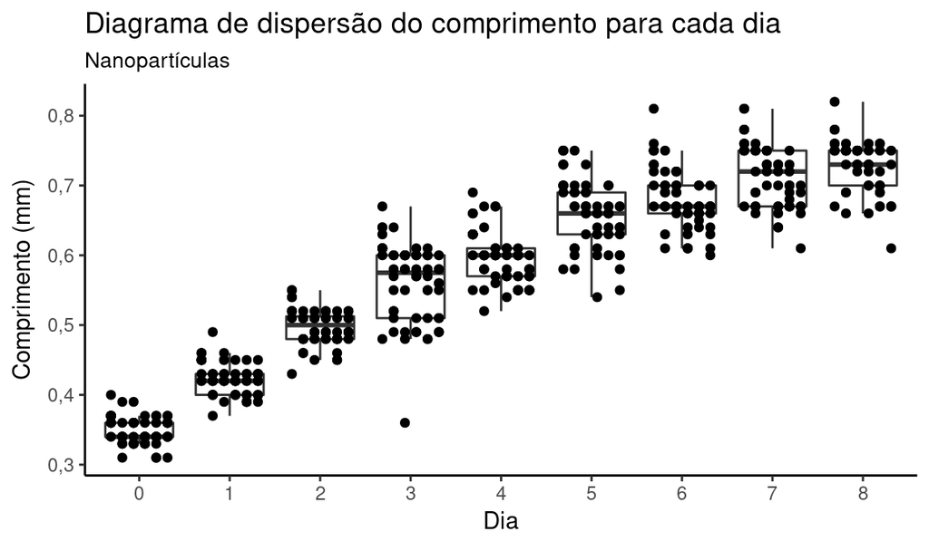

Diagrama de dispersão do comprimento para cada dia para nanopartículas. De imediato, nota-se as seguintes características: à medida em que se passam os dias o comprimento dos microcrustáceos aumentam e a variabilidade do comprimento é diferente entre os dias. Como as medidas dos comprimentos são muito próximas, caso os pontos nos diagramas de dispersão fossem centralizadas haveria a sobreposição destes e poderia gerar algum confundimento. Note que neste caso, o interesse é simplesmente avaliar o comportamento do comprimento nos dias independente do tratamento.

Pela observação dos diagramas de dispersão por dia e tratamento (figura 2) é possível destacar não somente o aumento do comprimento, como também diferentes taxas de crescimento do comprimento nos diferentes tratamentos. Por exemplo, observa-se pela figura 2, que a maneira pela qual ocorre o aumento do comprimento no tratamento 0 (controle) é maior ao longo dos dias e diferente quando comparado com o tratamento 5 (concentração de 0,1mg/L de nanopartículas).

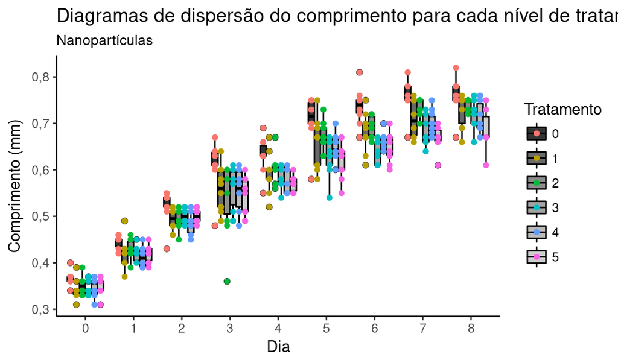

Diagrama de dispersão do comprimento para os níveis de tratamentos nos dias para nanopartículas. As cores na escala cinza dos indicam, do mais escuro (controle) ao mais claro (maior concentração), as diferentes concentrações de nanopartículas. Em geral, o comprimento do grupo controle é maior dentro de cada dia e no decorrer dos dias. O comprimento dos microcrustáceos nos dias de 5-8 (note a característica decrescente do comprimento para o mesmo dia entre os tratamentos), para os tratamentos de 1-5, é mais diferenciável em comparação com os dias 0-4 para os mesmos tratamentos. Assim como o gráfico anterior, a estrutura de variabilidade entre os dias é diferente e observa-se que para o mesmo dia há variação do comprimento para os diferentes tratamentos. É perceptível também que a taxa de crescimento do comprimento, para os diferentes tratamentos, é diferente.

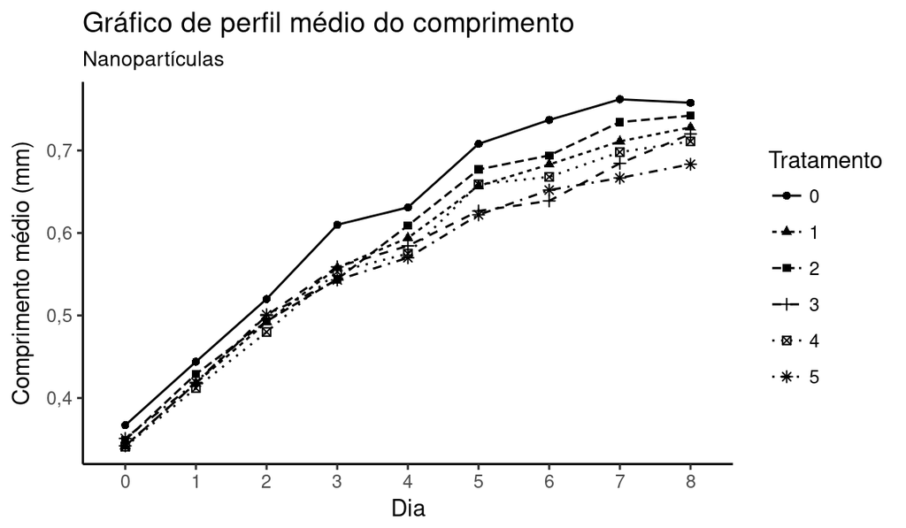

Gráfico de perfil médio do comprimento para nanopartículas. Nota-se que para o controle, referido como tratamento 0, o comprimento médio para os diferentes dias é superior quando comparado com os diferentes tratamentos. Observe que para o tratamento 2 (0.0125mg/L de nanopartículas) supera o comprimento médio dos demais tratamentos (3-5) a partir do 4 dia, abaixo somente do controle.

##Número de ovos e neonatos para nanopartículas

Observe nos gráficos a seguir, que o número médio de ovos e neonatos saem do valor zero nos dias 3 e 4, respectivamente, e passam a variar a partir destes.

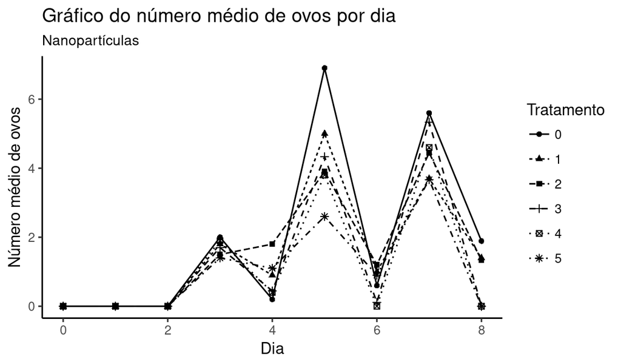

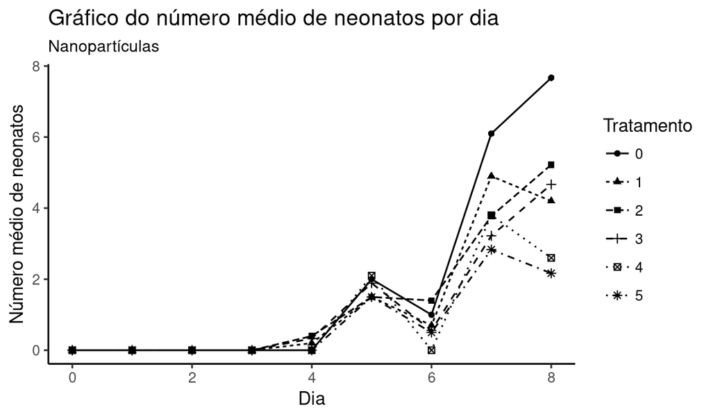

Gráfico do número médio de neonatos para nanopartículas. Assim como acontece para o número de ovos, pode-se observar que o tratamento 0 (controle) se destaca dos demais em relação ao número médio de neonatos por dia, com igual valor ou acima de todos os outros tratamentos em 7 dos 9 dias observados, e perde apenas no dia 4, no qual a média é zero para esse grupo e no dia 6, no qual o tratamento 2 (0,0125mg/L) teve uma média maior. Além disso, nota-se que para os outros tratamentos nao existe um que se destaca, uma vez que nenhum deles se mantêm predominantemente acima ou abaixo dos demais. É possível notar também que a partir do dia 6 os grupos 0 (controle), 2 (0,0125mg/L) e 3 (0,025mg/L) seguem uma tendência crescente no número médio de neonatos, enquanto nos outros grupos esse número cresce no dia 7, mas cai novamente no dia 8.

##Comprimento para sal de zinco

Assim como no caso das nanopartículas, os diagramas de dispersão do comprimento por dia (figura 6) e do gráfico de perfil médio (figura 8), exibem uma associação entre os valores do comprimento com o passar dos dias, ou seja, em geral ao longo dos dias aumenta-se o comprimento dos microcrustáceos. Além disso, também se verifica a característica de crescimento e possível estabilização do comprimento.

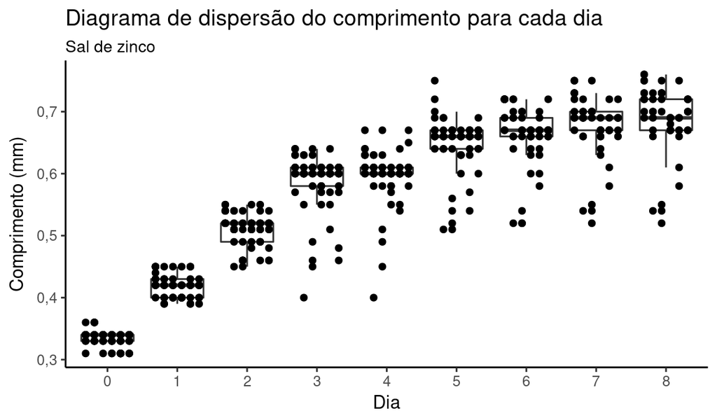

Diagrama de dispersão do comprimento para cada dia para sal de zinco. De imediato, nota-se as seguintes características: à medida em que se passam os dias o comprimento dos microcrustáceos aumentam e a variabilidade do comprimento é diferente entre os dias. Observa-se grande variabilidade a partir do dia 3 até o dia 8 (deve-se ter cuidado ao comparar com a figura 1, pois naquele caso as concentrações de nanopartículas são diferentes das do sal de zinco). Assim como anteriormente, as medidas dos comprimentos são muito próximas. Caso os pontos nos diagramas de dispersão fossem localizados no centro haveria a sobreposição destes e poderia gerar algum confundimento. Note que neste caso, o interesse é simplesmente avaliar o crescimento com o decorrer dos dias independente do tratamento.

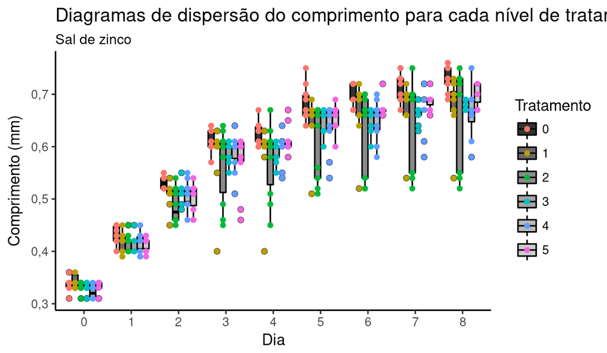

Diagrama de dispersão do comprimento para os níveis de tratamentos nos dias para sal de zinco. As cores na escala cinza indicam, do mais escuro (controle) ao mais claro (maior concentração), as diferentes concentrações de sal de zinco. Em geral, o comprimento do grupo controle é maior dentro de cada dia e no decorrer dos dias. Assim como o gráfico anterior, não só a estrutura de variabilidade entre os dias é diferente, mas também observa-se que para o mesmo dia há variação do comprimento para os diferentes tratamentos. Observe, além disso, que a taxa de crescimento do comprimento, para os diferentes tratamentos, são diferentes.

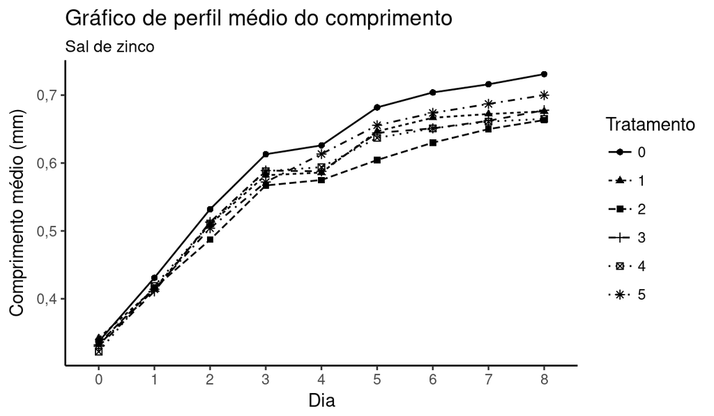

Gráfico de perfil médio do comprimento para sal de zinco. Nota-se que para o controle, referido como tratamento 0, o comprimento médio para os diferentes dias é superior quando comparado com os diferentes tratamentos. Observe que o tratamento 5 (0,09mg/L de sal de zinco) supera o comprimento médio dos demais tratamentos (1-4) a partir do 4 dia, abaixo somente do controle. Além disso, observe que o tratamento 2 (0,01 mg/L de sal de zinco) no decorrer dos dias possui o menor comprimento médio.

##Número de ovos e neonatos para sal de zinco

Observe nos gráficos a seguir, que o número médio de ovos e neonatos saem do valor zero nos dias 3 e 4, respectivamente, e passam a variar a partir destes (assim como no caso para nanopartículas).

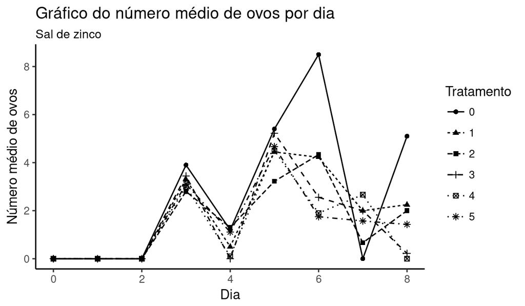

Gráfico do número médio de ovos por dia para sal de zinco. Assim como para as nanopartículas, neste gráfico pode-se observar que o tratamento 0 (controle) se destaca dos demais em relação ao número médio de ovos por dia, com igual valor ou acima de todos os outros tratamentos em 8 dos 9 dias observados, e perde apenas no dia 7, no qual a média é zero para esse grupo. Além disso, nota-se que para os outros tratamentos nao existe um que se destaca, uma vez que nenhum deles se mantêm predominantemente acima ou abaixo dos demais.

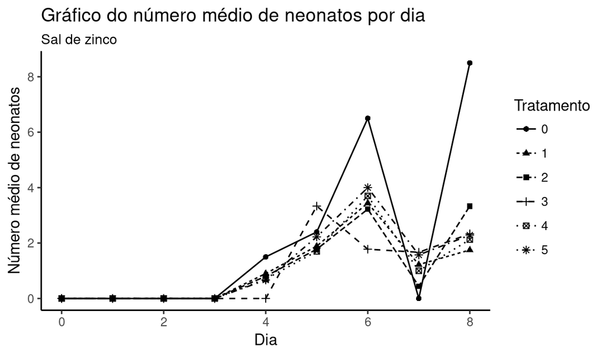

##Avaliação da concentração 0,006mg/L para nanopatículas e sal de zinco

Os gráficos a seguir representam os comportamentos diários do comprimento, do comprimento médio (por dia), do número médio de ovos e neonatos para o tratamento 1 (concentração 0,006mg/L) para nanopartículas e sal de zinco. Deseja-se verificar possíveis diferenças e similaridades na mesma concentração para as diferentes partículas.

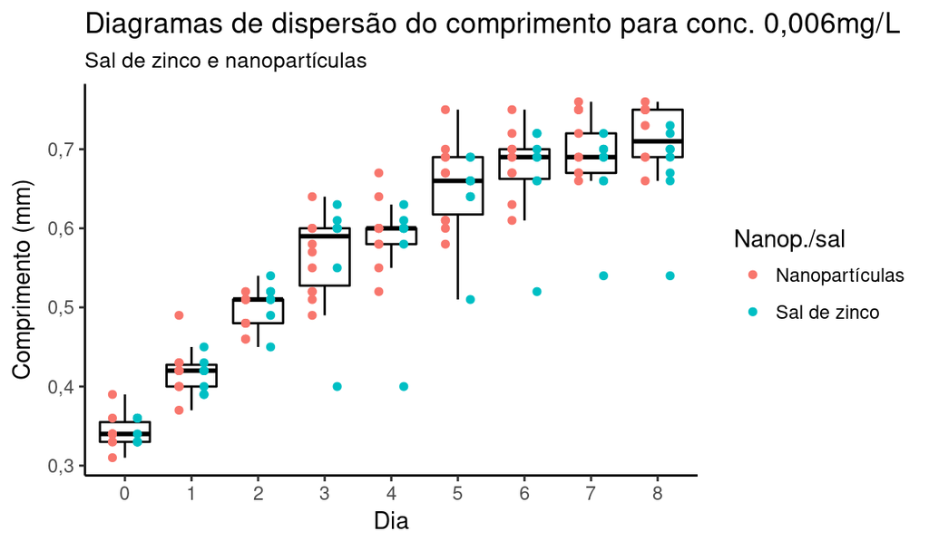

Como observado anteriormento, com o passar dos dias o comprimento dos microcrustáceos tem uma característica crescente. Nos dias 0 e 1, a variabilidade do comprimento para sal de zinco é menor quando comparada com nanopartículas e a partir do dia 2 torna-se maior. Veja que, a partir do dia 3 até o dia 8, existem pontos que se destacam para o sal de zinco. A menos destes pontos, percebe-se que a estrutura de variabilidade se reduz, e inclusive, é menor quando comparado com nanopartículas.

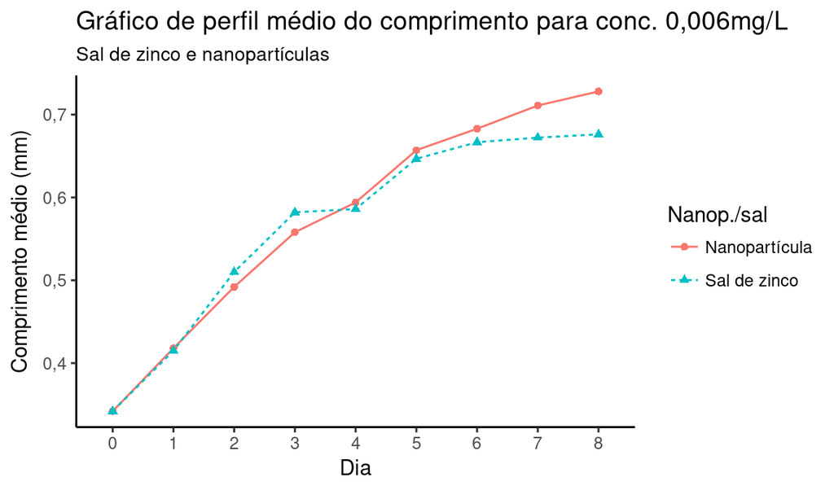

Nota-se que o comprimento médio para sal de zinco só é superior para os dias 2 e 3 em relação à nanopartículas. Além disso, em geral as diferenças entre os valores do comprimento médio são pequenas ao longo dos dias, com maior valor para o dia 8. Embora sejam partículas diferentes, na mesma concentração, a relação com o comprimento médio não é muito diferente.

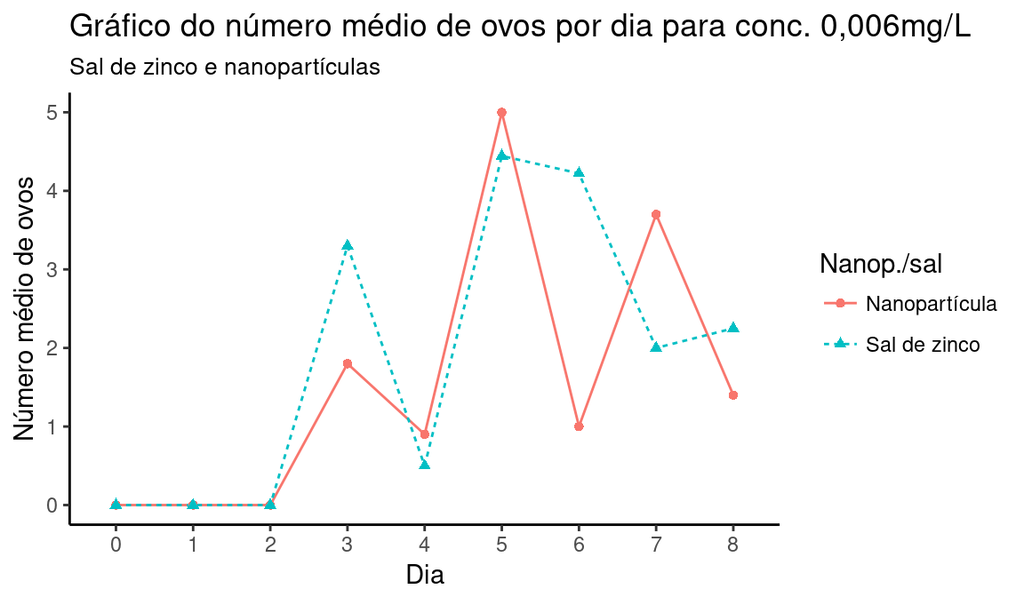

O número médio de ovos para sal de zinco é superior somente para os dias 3, 6 e 8 em relação à nanopartículas. A partir do terceiro dia há variação do número de ovos, para ambas as partículas.

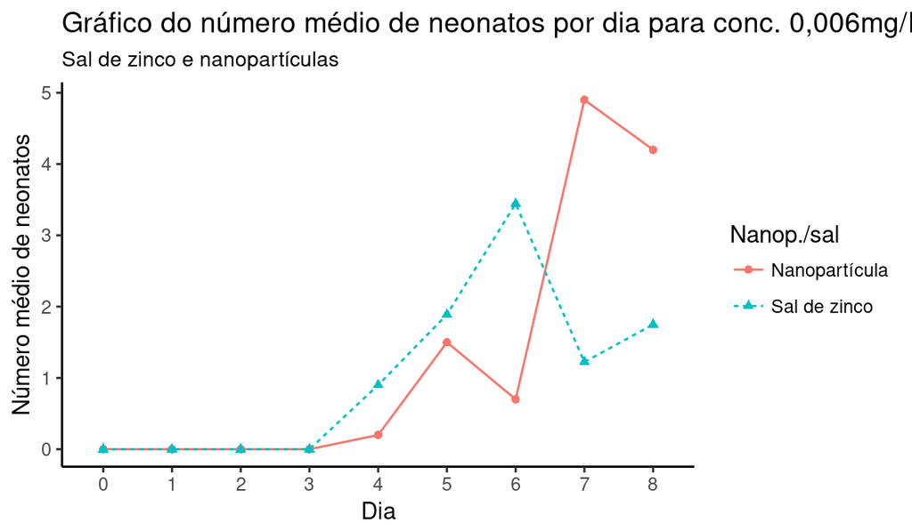

Ao contrário do número médio de ovos, no gráfico anterior, o número médio de neonatos para nanopartículas somente é superior nos dias 7 e 8, comparado com sal de zinco. A partir do quarto dia há variação do número médio de neonatos (para ambas as partículas) e veja a tendência crescente para sal de zinco até o dia 6.

#Considerações sobre a modelagem

De acordo com as informações obtidas sobre o projeto, as variáveis dia e concentração (para nanopartículas e sal de zinco) são bem conhecidas, enquanto que as replicações (microcrustáceos) são obtidas de uma maneira aleatória. Com isso, a utilização de modelos mistos, que apresentam tanto fatores de efeitos fixos (dia e concentração) quanto aleatórios (replicações), foi a linha de raciocínio utilizada para o estudo.

##Modelagem para a variável comprimento

##Nanopartículas

Depois de avaliado diferentes propostas de modelos, com diferentes distribuições dos erros, diferentes funções de ligação e estrutura de variância, dois deles foram destacados. Nestes, de acordo com a análise descritiva, consideram a interação entre as variáveis de efeito fixo (dia e tratamento (diferentes concentrações de nanopartículas)) e os erros foram considerados normais com diferentes funções de ligação, a inversa (modelo 1) e a logarítmica (modelo 2).

Para avaliar o modelo foram considerados os gráficos de quantil dos resíduos pelo quantil teórico da normal padrão. Espera-se que grande parte dos resíduos estejam próximo da linha de referência vermelha e também dentro da linha tracejada vermelha (referida como banda de confiança).

Para o modelo 1 é possível ver que nos extremos, os resíduos não estão próximos da linha de referência e não estão dentro da banda de confiança (figura 15). Para o modelo 2, nota-se que os pontos estão mais próximos da linha de referência e dentro da banda de confiança para o extremo superior (observar figura 16 e comparar com a figura 15). No extremo inferior mais pontos estão fora da banda de confiança e mais distante da linha de referência quando comparado com o modelo 1 (observar figuras 16 e 15). Isto, por fim, nos indica que as caudas para a distribuição dos resíduos são pesadas para o modelo 1, enquanto que para o modelo 2, a cauda esquerda é a mais pesada.

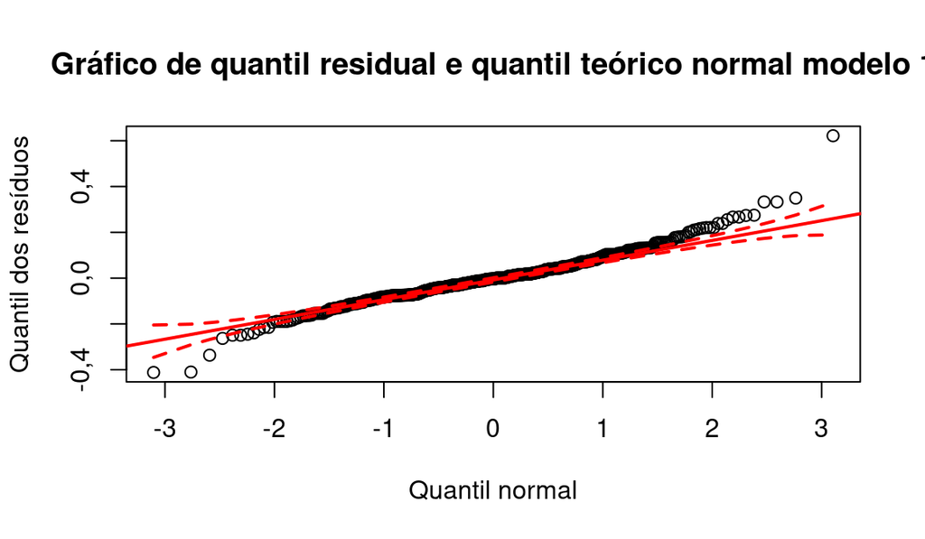

Gráfico de quantil dos resíduos pelo quantil teórico da distribuição normal padrão para o modelo 1. Os resíduos foram obtidos a partir do modelo que considerou os erros normalmente distribuídos e com a função de ligação inversa. Nota-se que muitos dos pontos localizados nos extremos estão fora da banda de confiança.

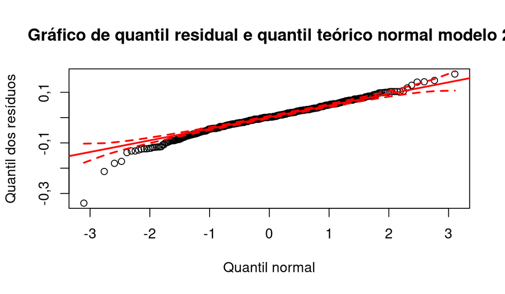

Gráfico de quantil dos resíduos pelo quantil teórico da distribuição normal padrão para o modelo 2. Os resíduos foram obtidos a partir do modelo que considerou os erros normalmente distribuídos e com a função de ligação logarítmo. Neste caso, muitos dos pontos localizados no extremo inferior estão fora da banda de confiança, enquanto houve uma melhora no extremo superior, onde os resíduos ficatam mais próximos da banda de confiança quando comparado com o modelo anterior.

Com o objetivo de analisar a variabilidade dos resíduos os gráficos de resíduos por valores ajustados foram considerados e pode-se perceber a não uniformidade da variância residual para o modelo 1 (e maior quando comparada com o modelo 2), enquanto que para o modelo 2 a variabilidade do resíduo é uniforme. Verifica-se também a concentração dos resíduos do modelo 1 em um intervalo aproximado de ($-0,4$; $0,4$) e do modelo 2 ($-0,2$;$0,2$).

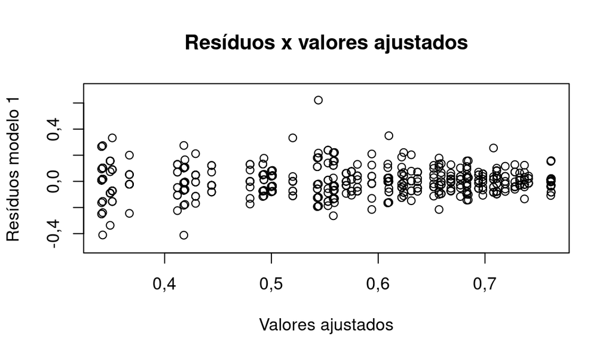

Gráficos dos resíduos pelos valores ajustados do modelo 1. Note que à medida em que os valores ajustados aumentam a variabilidade dos resíduos diminui. Isto representa a não uniformidade dos resíduos.

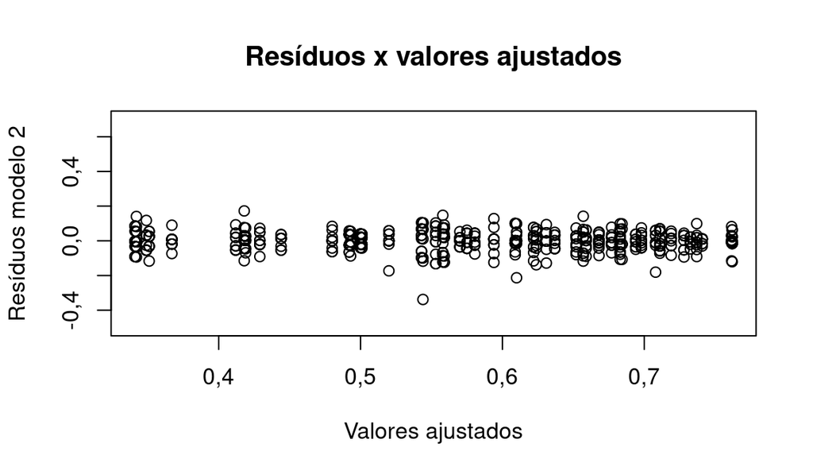

Gráficos dos resíduos pelos valores ajustados do modelo 2. Neste caso a variabilidade dos resíduos aparenta ser mais uniforme e menor que a do modelo1. Além disso, os valores dos resíduos são menores quando comparado com o modelo 1.

Nos histogramas a seguir, é possível observar uma característica simétrica dos resíduos ao redor do zero, para ambos os modelos, no entanto, a simetria só não é mais destacada, porque existem pontos residuais que são mais extremos em relação ao zero. Isto é o reflexo dos gráficos de quantis nas figuras 15 e 16. Como alguns resíduos estão fora da banda de confiança nos extremos, as caudas são pesadas.

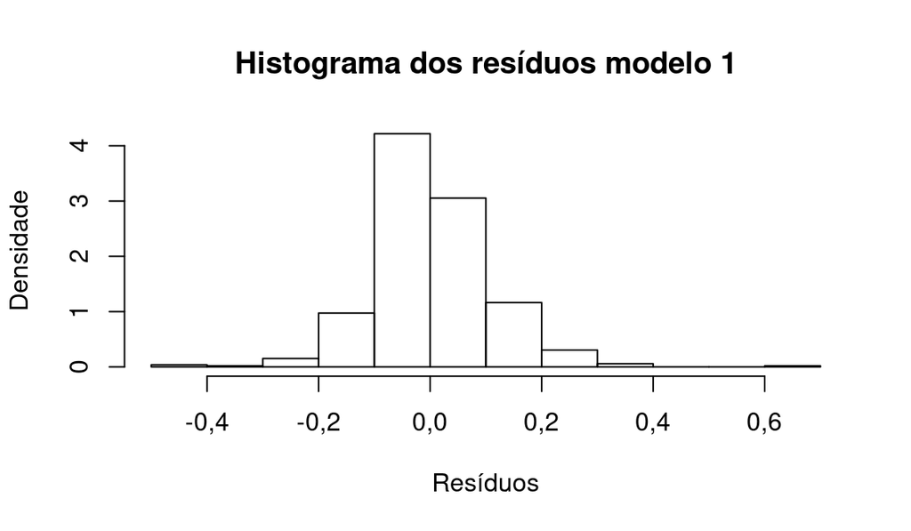

Histograma dos resíduos para o modelo 1. Nota-se uma simetria ao redor de zero com caudas pesadas, um relfexo do gráfico de quantil da figura 15.

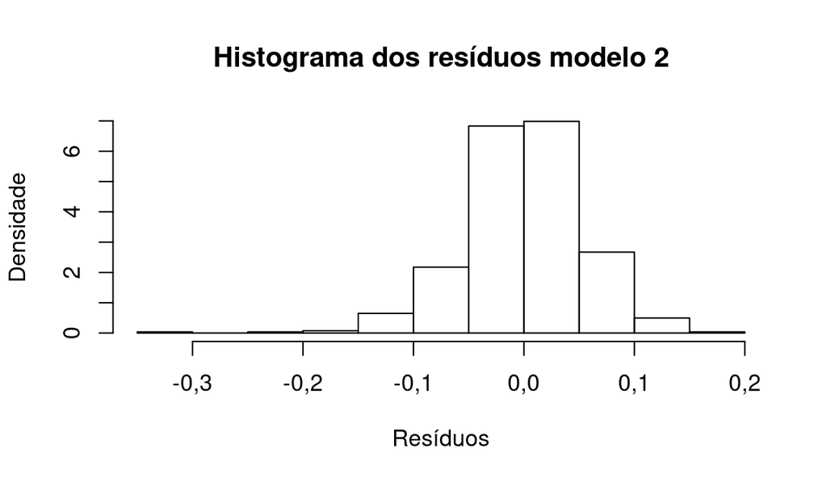

Histograma dos resíduos para o modelo 2. Nota-se uma simetria ao redor de zero com cauda pesada à esquerda, um relfexo do gráfico de quantil da figura 16.

Pelos histogramas anteriores é possível avaliar o comportamento geral dos resíduos. Pode-se, mais do que isso, verificar o comportamento residual para os diferentes tratamentos e para os dias, para cada modelo. Nas figuras 21 e 22 avaliou-se os resíduos dentro de cada tratamento para os modelos 1 e 2, respectivamente. Nas figuras 23 e 24 verificou-se os resíduos para os dias para os modelos 1 e 2.

Observe que os gráficos de resíduos por tratamento indicam características de subestimação e superestimação (pontos em destaque nos diagramas de dispersão) para os modelos 1 e 2, respectivamente. Nota-se, entretanto, melhores ajustes para o modelo 2, pois para os tratamentos 4 e 5 nenhum ponto estimado diferia muito dos demais, e menor foi a quantidade de valores superestimados.

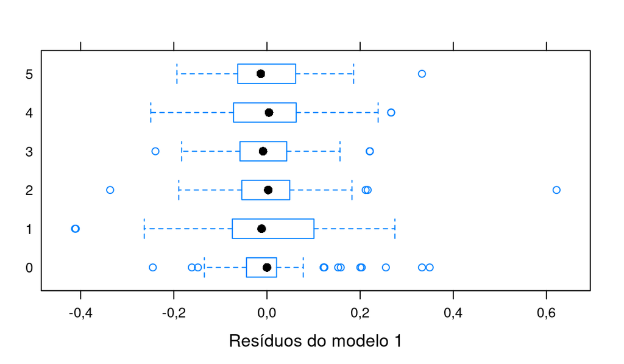

Diagramas de dispersão dos valores residuais para os diferentes tratamentos, com destaque para o tratamento 0 (controle).

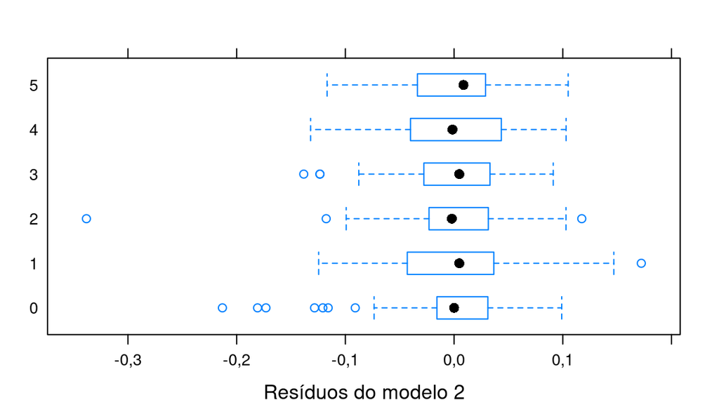

Diferentemente do modelo 1, neste caso para os tratamentos 4 e 5 pode-se verificar que não existe pontos extremos. Nos demais casos tais pontos estão presentes, mas em menor quantidade em relação ao modelo 1. Possivelmente isto indica um melhor ajuste do modelo 2.

Veja que os gráficos de resíduos por dia para os dois modelos propostos seguem a mesma linha de raciocínio dos anteriores. Ou seja, subestimação e superestimação para os modelos 1 e 2, respectivamente, para os diferentes dias.

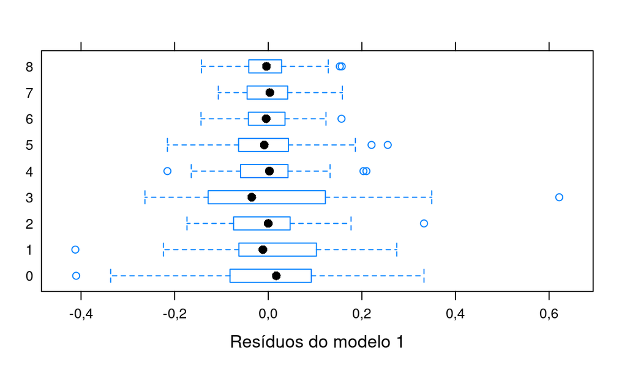

Diagramas de dispersão dos resíduos para os dias. Como muitos valores dos comprimentos foram subestimados em relação aos valores observados, existem pontos que se destacam para diferentes dias e são maiores que zero.

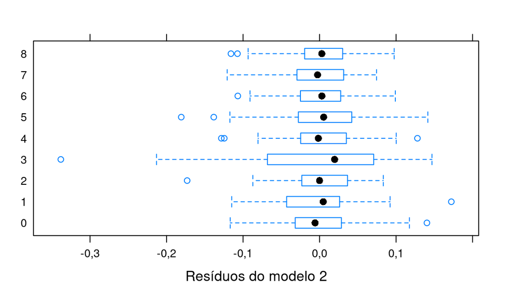

Diagramas de dispersão dos resíduos para os dias. Como muitos valores dos comprimentos foram superestimados em relação aos valores observados, existem pontos que se destacam para diferentes dias e são menores que zero.

##Sal de zinco

Para sal de zinco, o melhor modelo enontrado foi com distribuição normal do erro, função de ligação logarítmica e estrutura de correlação AR(1). Apesar disso, pelo gráfico de resíduos pode-se observar que muitos valores são superestimados, ou seja, a diferença entre os valores observados e estimados são menores que zero. Observe que muitos dos resíduos estão fora da banda de confiança e distantes da linha de referência no gráfico de quantis. Consequentemente, a cauda à esquerda da distribuição dos resíduos é pesada.

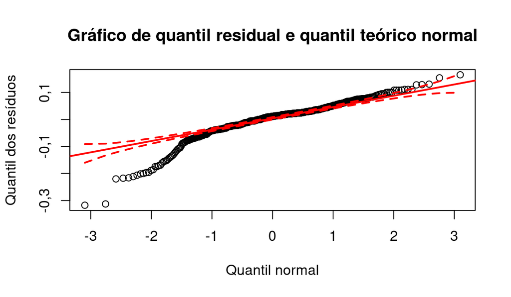

Gráfico de quantil dos resíduos pelo quantil teórico da distribuição normal padrão para o modelo proposto. Os resíduos foram obtidos a partir do modelo que considerou os erros normalmente distribuídos e com a função de ligação logarítmica. Nota-se que muitos dos pontos localizados no extremo esquerdo (superestimação dos comprimentos) estão fora da banda de confiança. Isto faz com que a cauda à esquerda dos resíduos seja pesada.

Ao se avaliar, por exemplo, o modelo com função de ligação inversa, pôde-se notar que a cauda à direita da distribuição do quantil é pesada (subestimação dos resíduos). Além disso, a variabilidade dos resíduos com tal função de ligação é maior em relação à ligação logarítmica. Observe, pelo gráfico a seguir, que a variabilidade dos resíduos concentra-se em grande parte no intervalor (-0,1; 0,1), com alguns pontos residuais, principalmente, abaixo de -0,1.

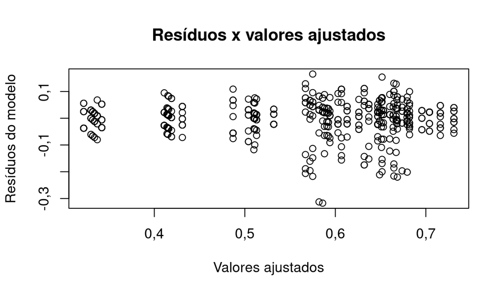

Gráfico dos resíduos pelos valores ajustados (estimados). Note que existe maior concentração dos resíduos no intervalo (-0,1; 0,1) e alguns deles estão abaixo de -0,1 (o que representa que os valores ajustados superestimam os valores observados dos comprimentos).

Foi possível identificar menos assimetria da distribuição dos resíduos com a função de ligação logarítmica, como mostrado na figura abaixo. Isto se deve, pois os valores ajustados superestimam os valores observados. Veja que a menos de alguns destes pontos, a característica de normalidade é considerável.

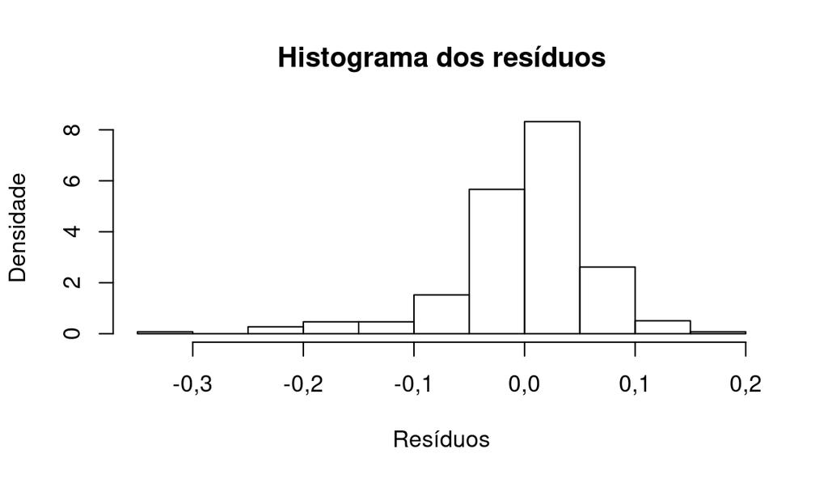

Histograma dos resíduos. Veja que alguns resíduos menores que zero fazem com que a distribuição residual seja assimétrica (superestimação dos valores observados).

Assim como feito na análise do modelo para nanopartículas, mais do que verificar os resíduos de maneira geral, será avaliado o comportamento residual por tratamento e dia.

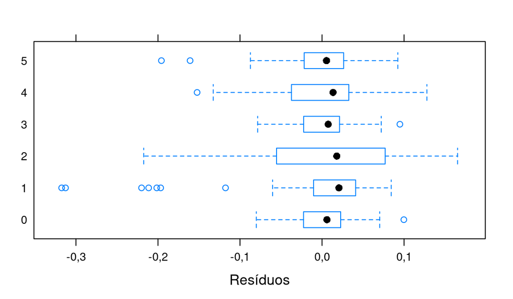

Diagramas de dispersão para os diferentes tratamentos. Veja que a avaliação do ajuste baseado nesta análise é razoável, alguns pontos diferirem dos observados, apesar de muitos deles serem superestimados para o tratamento 1.

A avaliação dos resíduos por dia indicou ajuste razoável para os dias 0, 1 e 2. Entretanto, ao se observar para os demais dias nota-se que muitos dos comprimentos foram superestimados (pontos que se destacam em cada diagrama nos diferentes dias).

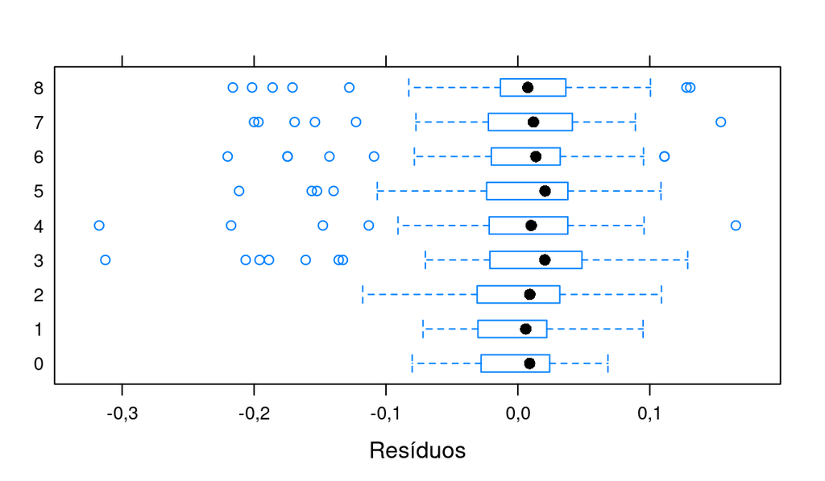

Diferentemente do gráfico dos resíduos por tratamento, aqui pode-se identificar limitações do ajuste por dia. Veja que, com exceção dos dias 0, 1 e 2, nos demais dias muitos valores ajustados são maiores que os observados.

#Anexos